# Table of Contents

### Riemann Surfaces

$Arg(z)$ as imaginary part of the complex logarithm is multi-valued, as mentioned above. On computers only the principal value $arg(z)$ is implemented, which has values between -\pi and \pi. At the negative real axis there thus results a jump between these two values, which can be clearly seen in the visualization.

There is a way to make the complex logarithm continouos (and differentiable) at the negative real axis. When approaching this axis with positive real numbers, switch to $Ln(z)$ with imnaginary part $arg(z)+2\pi$. When approaching with negative real values, switching to the logarithm with imaginary part $arg(z)-2\pi$ does the trick. Hoeever, there is a flaw: the method works on the negative x-axis, but creates a jump on the positive axis.

The underlying problem is that the logarithm is not an analytic function from $\mathbb{C} \to \mathbb{C}$. The principal value is anaytic on $\mathbb{C}$ without the negative real axis. One method to obtain an complex analytic function is to extend the definition set. For this purpose one can imagine the defining complex surface glued at the negative real axis to other complex planes. For each $n \in \mathbb{Z}$ a branch of the defining surface of $Ln(z)$ can be glued. The picture below illustrates the procedure.

[figure not shown]

This is a prominent example of the concept of **Riemann Surfacess**, named after the famous German mathematician Bernhard Riemann (1826-1866). For each $n \in \mathbb{Z}$ the corresponding $Ln$ function is called a branch of the Riemann surface. The negative real axis is a $branch cut$, because branches have to be glued there in order to obtain the Riemann surface.

Another example of a Riemann surface evolves from the complex squareroot. The following shows the contour plots of $\sqrt{z}$.

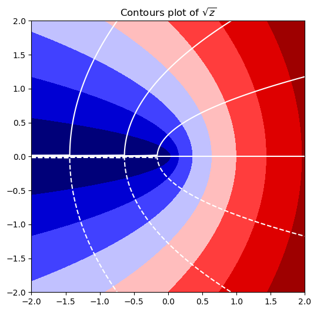

```python
x = np.linspace(-2, 2, 100)
X, Y = np.meshgrid(x, x)
Z = X + 1j * Y
F = np.sqrt(Z)

fig, ax = plt.subplots(figsize=(6,6))
plt.contourf(X, Y, np.real(F),cmap='seismic')
plt.contour(X, Y, np.imag(F),colors='white')
ax.set_title('Contours plot of $\sqrt{z}$')
plt.show()
```

Here the surface plots for it's real and imaginary parts:

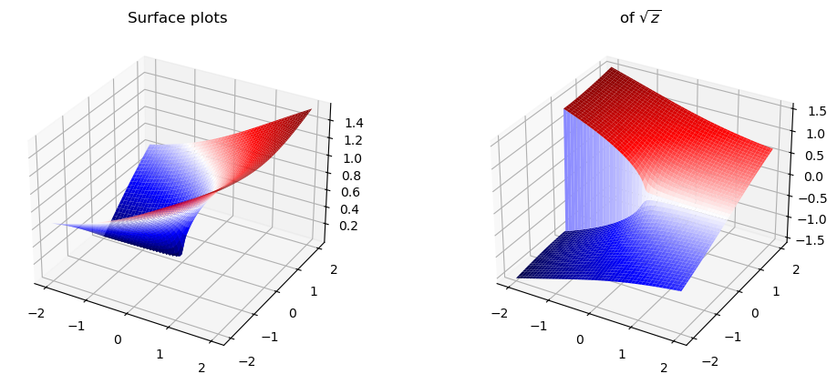

```python
from mpl_toolkits import mplot3d
x = np.linspace(-2, 2, 100)
X, Y = np.meshgrid(x, x)
Z = X + 1j * Y
F = np.sqrt(Z)

fig = plt.figure(figsize=plt.figaspect(0.4))
ax = fig.add_subplot(1,2,1,projection='3d')
ax.plot_surface(X, Y, np.real(F), cmap='seismic')
ax.set_title('Surface plots')
ax = fig.add_subplot(1,2,2,projection='3d')
ax.plot_surface(X, Y, np.imag(F), cmap='seismic')
ax.set_title('of $\sqrt{z}$')
plt.show()
```

The Riemann surface of the squareroot function is illustrated in the following figure:

[figure not shown]

### Graphic Export

'Matplotlib' allows easy export of graphics to files. Use the 'savefig' command with options, as shown in the cell below. Simply use the extension in the filename to determine the file type. In pixel graphics the resolution (dpi) can be specified as additional parameter. The following example also specifies transparency.

```python
plt.savefig("test.png", dpi=300, transparent=True)
```

In order to obtain figures of better quality it is recommanded to save the figure using the commands from the matplotlib library. As an example the following command saves a figure in the 'svg' format. This is a vector format, which has the advantage that it doesn't loose resolution when the size is changing.

```python
plt.savefig("test.svg", format="svg")
```

One may also store in pdf-format to obtain vector graphics.